# Introduction to R

## Recap

Yesterday we learned…

- Bash
- (Perl)
- (Python)

Today…

- R!

## NOT ANOTHER BLOODY LANGUAGE

## Getting by with programming languages

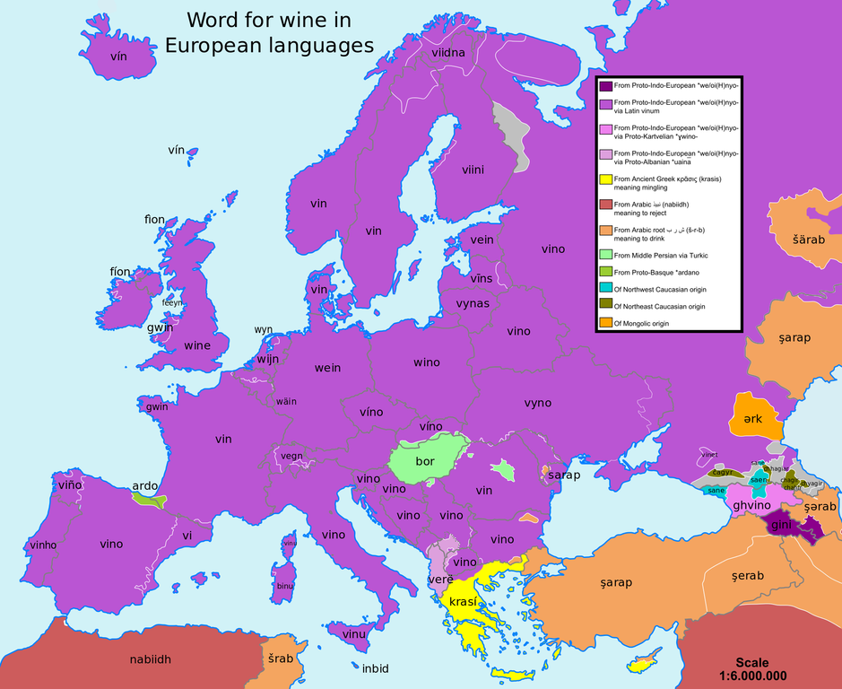

## Today we go from this…

```r
x <- 1 + 1
x
```

```
## [1] 2
```

## To this…

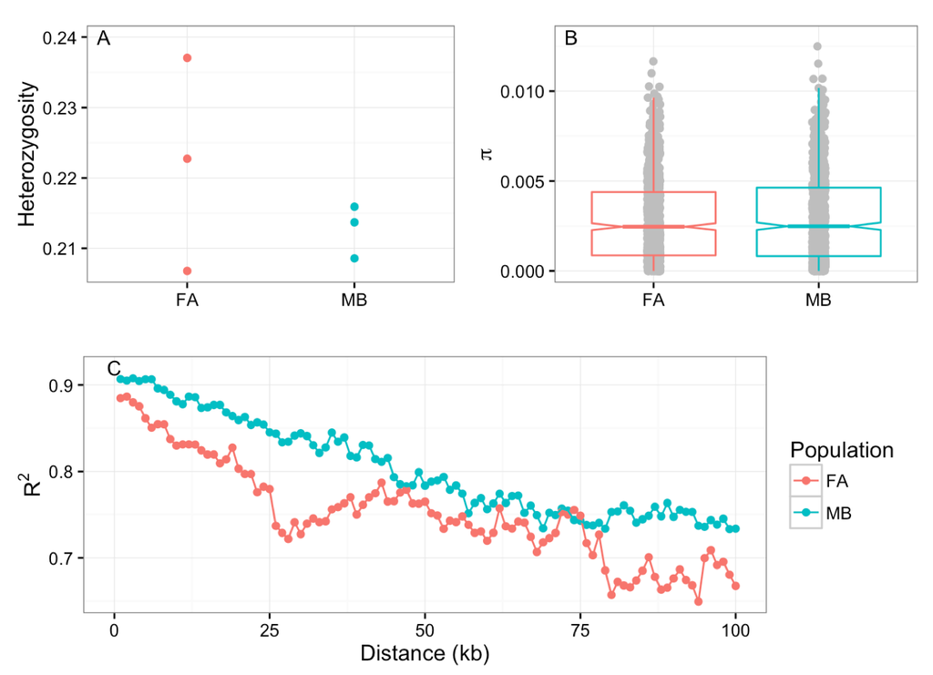

## Outline

- What is R and why is it so great?
- What does R do?
- How does R work?

## What is R?

## What is R?

R is an integrated suite of software facilities for data manipulation, calculation and graphical display. Among other things it has:

- an effective data handling and storage facility
- a large, coherent, integrated collection of tools for data analysis
- graphical facilities for data analysis and display
- a well developed, simple and effective programming language

https://cran.r-project.org/doc/manuals/r-release/R-intro.pdf

## Why use R?

## Why use R?

R is:

- Free
- Popular
- Powerful
- Flexible
- Well supported

https://www.r-bloggers.com/why-use-r-five-reasons/

## R is free

- Users have the freedom to run, copy, distribute, study, change and improve the software.
- Free as in "free speech" not "free beer"
- Part of the GNU project (along with Linux, Gimp etc.)

https://www.gnu.org/

## R is popular

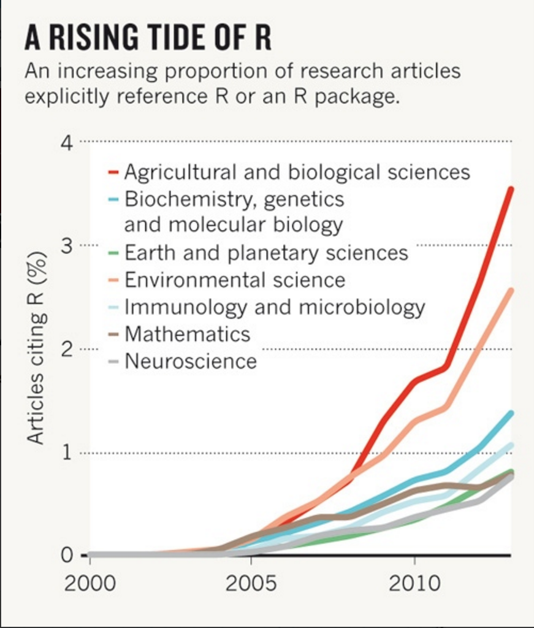

http://www.nature.com/news/programming-tools-adventures-with-r-1.16609

## R is powerful

- Can handle big data
- Can perform complex simulations
- Can be used with High Performance Clusters

## R is flexible

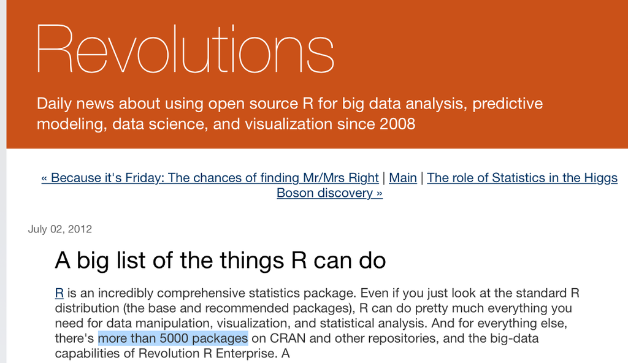

http://blog.revolutionanalytics.com/2012/07/a-big-list-of-the-things-r-can-do.html

## R is well supported

- Extensive built-in help
- Tutorials with packages
- Stack overflow
- R bloggers
- Twitter (#Rstats)

## What does R do?

## What can I do in R?

- Simulate and generate data
- Read, process and manipulate data
- Data analysis and statistics
- Make beautiful plots and graphics
- Write papers, reports and presentations (R markdown)

## Simulate and generate data

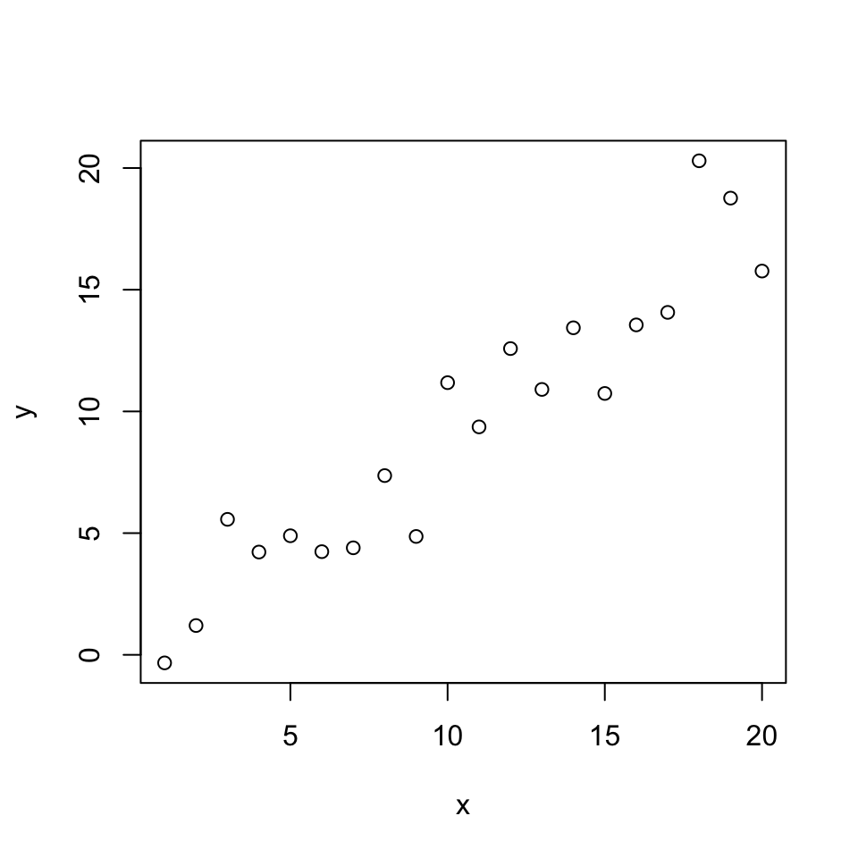

## Simulate and generate data

[figure not shown]

## Read, process and manipulate data

- Read in text files and tables
- Reformat tables
- Add new variables
- Recode variables
- Condense data
- Summarise data
- Link data tables
- Check for errors
- Clean data

## Data analysis and statistics

- Linear models, mixed models
- Bayesian models
- Spatial analysis
- Phylogenetics
- Population genetics
- Quantitative genetics

## How does R work?

## Our aim

- Manipulate and analyse *numbers*
- Manipulate and analyse *text*

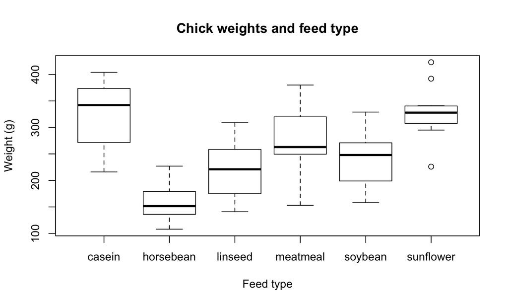

## R and Unix

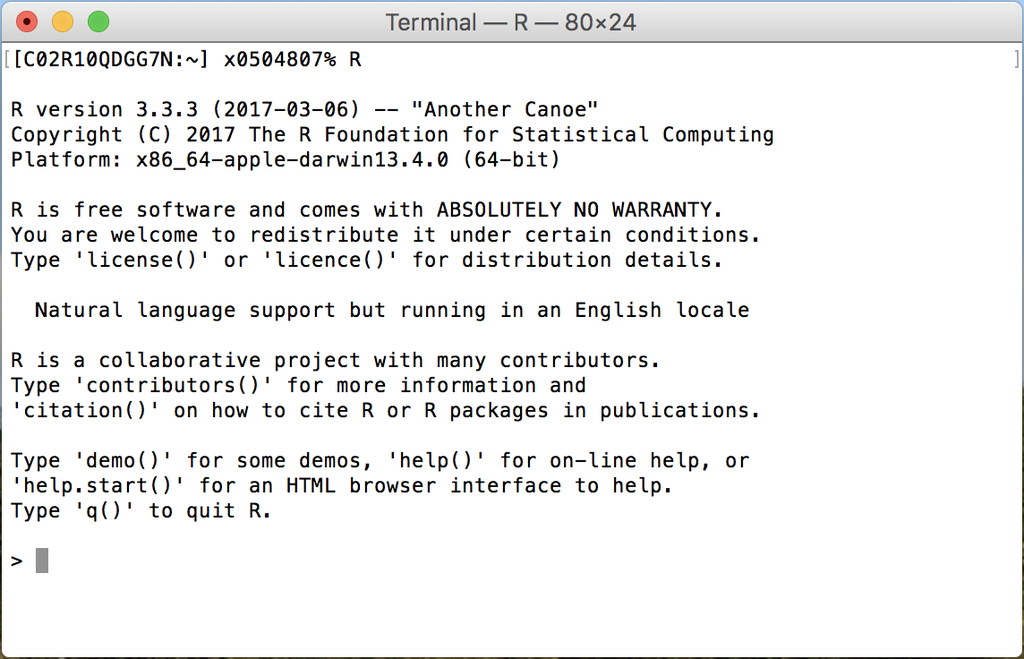

## R is a calculator

```r
4 + 7
```

```
## [1] 11
```

## R objects

```r
x <- 4
x
```

```
## [1] 4
```

```r
rm(x)
x
```

```
## Error in eval(expr, envir, enclos): object 'x' not found
```

## R objects

```r
x <- 4
x + 7
```

```
## [1] 11
```

## R objects

```r
x <- 4
y <- 7
x + y
```

```
## [1] 11
```

## Characters

```r
hello
```

```
## Error in eval(expr, envir, enclos): object 'hello' not found
```

```r
"hello"
```

```
## [1] "hello"
```

```r
"hello world"
```

```
## [1] "hello world"
```

## Characters

```r
x <- "Martin has a bushy beard"
x
```

```
## [1] "Martin has a bushy beard"
```

## Characters

```r
x <- "cats"
y <- "dogs"

x + y
```

```
## Error in x + y: non-numeric argument to binary operator
```

```r
"1" + "2"
```

```
## Error in "1" + "2": non-numeric argument to binary operator
```

## Vectors

```r
x <- c(6,7,8)
x
```

```
## [1] 6 7 8
```

```r
y <- c(1:10)
y
```

```
##  [1]  1  2  3  4  5  6  7  8  9 10
```

```r
z <- c("cats","cats","dogs")
z
```

```
## [1] "cats" "cats" "dogs"
```

## Vectors

Vectors can consist of numbers or characters, but not both

```r
x <- c(1,2,"cats")
x
```

```
## [1] "1"    "2"    "cats"
```

## Vectors

```r
x <- c(1:10)
x/2
```

```
##  [1] 0.5 1.0 1.5 2.0 2.5 3.0 3.5 4.0 4.5 5.0
```

```r
y <- c(101:110)
z <- x*y
z
```

```
##  [1]  101  204  309  416  525  636  749  864  981 1100
```

## Vectors

```r
x <- c(1,2,4,4,4,5)

x[5]
```

```
## [1] 4
```

```r
x[c(4:6)]
```

```
## [1] 4 4 5
```

## Vectors

```r
x <- "Martin has a bushy beard"
x[1]
```

```
## [1] "Martin has a bushy beard"
```

```r
x[2]
```

```
## [1] NA
```

## Vectors

```r
x <- c("Martin","has","a","bushy","beard")
x[1]
```

```
## [1] "Martin"
```

```r
x[2]
```

```
## [1] "has"
```

```r
x[c(3:5)]
```

```
## [1] "a"     "bushy" "beard"
```

## Matrices

```r
x <- matrix(0,ncol = 6,nrow = 2)
x
```

```
##      [,1] [,2] [,3] [,4] [,5] [,6]
## [1,]    0    0    0    0    0    0
## [2,]    0    0    0    0    0    0
```

```r
x <- matrix(c(1:12),ncol = 4,nrow = 3)
x
```

```
##      [,1] [,2] [,3] [,4]
## [1,]    1    4    7   10
## [2,]    2    5    8   11
## [3,]    3    6    9   12
```

## Matrices

```r
x <- c("cats","cats","cats","cats","dogs","dogs")
m <- matrix(x,
            ncol = 3,nrow = 2)
m
```

```
##      [,1]   [,2]   [,3]
## [1,] "cats" "cats" "dogs"
## [2,] "cats" "cats" "dogs"
```

```r
m <- matrix(x,
            ncol = 3,nrow = 2,byrow = T)
m
```

```
##      [,1]   [,2]   [,3]
## [1,] "cats" "cats" "cats"
## [2,] "cats" "dogs" "dogs"
```

## Matrices

```r
m
```

```
##      [,1]   [,2]   [,3]
## [1,] "cats" "cats" "cats"
## [2,] "cats" "dogs" "dogs"
```

```r
m[2,]
```

```
## [1] "cats" "dogs" "dogs"
```

```r
m[,3]
```

```
## [1] "cats" "dogs"
```

## Matrices

```r
m
```

```
##      [,1]   [,2]   [,3]
## [1,] "cats" "cats" "cats"
## [2,] "cats" "dogs" "dogs"
```

```r
m[2,3]
```

```
## [1] "dogs"
```

## Functions

- `c()`, and `matrix()` are *functions*.
- Arguments for functions always enclosed within brackets after function name
- Can be built-in or written ourselves

## Some useful functions

```r
x <- seq(from = 0,to = 1000,by = 100)
str(x)
```

```
##  num [1:11] 0 100 200 300 400 500 600 700 800 900 ...
```

```r
sum(x)
```

```
## [1] 5500
```

```r
length(x)
```

```
## [1] 11
```

## Functions

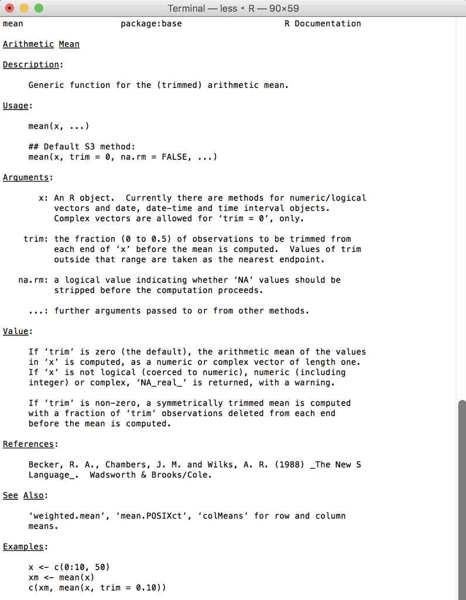

```r
?mean
```

## Factors

```r
x <- c("red","red","red","blue","blue","green")
str(x)
```

```
##  chr [1:6] "red" "red" "red" "blue" "blue" "green"
```

```r
x1 <- factor(x)
str(x1)
```

```
##  Factor w/ 3 levels "blue","green",..: 3 3 3 1 1 2
```

## Data frames

```r
Sweet_colours <- c("Red","Purple","Yellow","Green")
Number_eaten <- c(21,18,3,4)
Number_left <- c(0,1,20,23)

sweets <- data.frame(Sweet_colours,Number_eaten,Number_left)

sweets
```

```
##   Sweet_colours Number_eaten Number_left
## 1           Red           21           0
## 2        Purple           18           1
## 3        Yellow            3          20
## 4         Green            4          23
```

## Data frames

```r
str(sweets)
```

```
## 'data.frame':    4 obs. of  3 variables:
##  $ Sweet_colours: Factor w/ 4 levels "Green","Purple",..: 3 2 4 1
##  $ Number_eaten : num  21 18 3 4
##  $ Number_left  : num  0 1 20 23
```

```r
nrow(sweets)
```

```
## [1] 4
```

```r
ncol(sweets)
```

```
## [1] 3
```

## Data frames

```r
sweets[2,]
```

```
##   Sweet_colours Number_eaten Number_left
## 2        Purple           18           1
```

```r
sweets[,2]
```

```
## [1] 21 18  3  4
```

```r
sweets[2,2]
```

```
## [1] 18
```

## Data frames

```r
sweets$Sweet_colours
```

```
## [1] Red    Purple Yellow Green
## Levels: Green Purple Red Yellow
```

```r
sweets[,"Sweet_colours"]
```

```
## [1] Red    Purple Yellow Green
## Levels: Green Purple Red Yellow
```

## Data frames

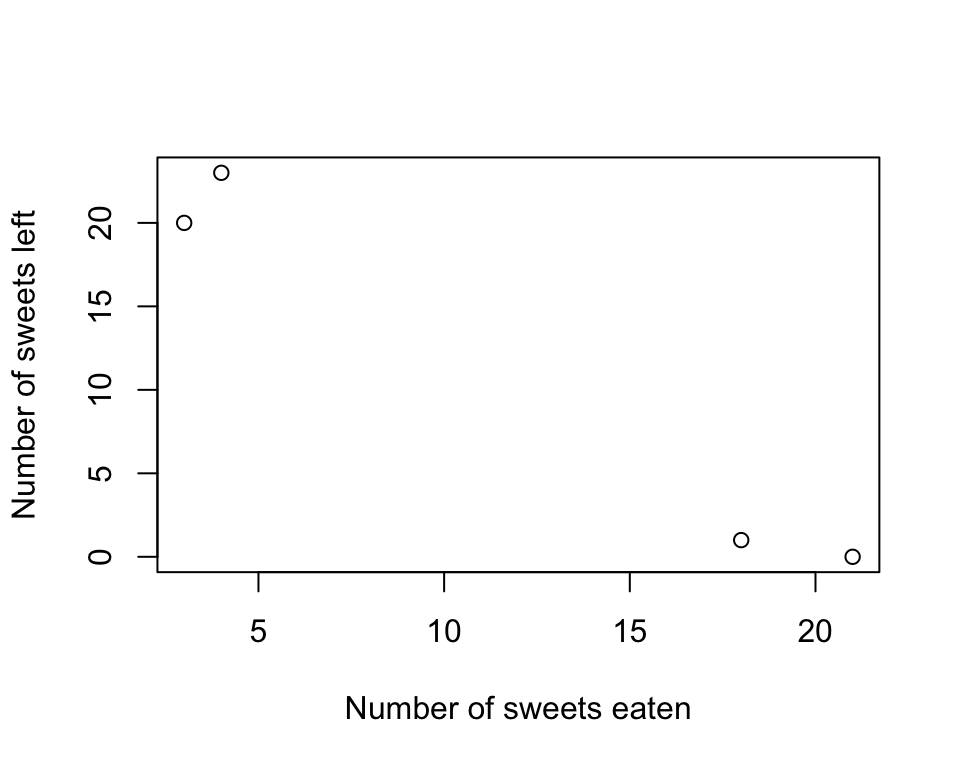

```r
plot(Number_left~Number_eaten,data = sweets,
     xlab = "Number of sweets eaten",
     ylab = "Number of sweets left")
```

## R scripts

`Rscript`

```r
quit()

nano
<write your R script>

Rscript myscript.R
```

## Your turn

## Your turn

- Open *Intro_to_R_practical.pdf*
- Follow the instructions!